# Self-reported expressibility predicts communicative success: Open dataset, validation, and simulation

Modelling script

Aleksandra Ćwiek, Susanne Fuchs, Wim Pouw, and Šárka Kadavá

2025-06-01

# 1 Source setup

```r
# current folder (first go to session -> set working directory -> to source file location)
parentfolder <- dirname(getwd())

#################### packages ####################

required_packages <- c("tidyverse", # data wrangling
                       "readxl",
                       "furrr",
                       "stringr",
                       "broom", # for tidy model outputs
                       "rstan",
                       "brms",
                       "cmdstanr",
                       "HDInterval", # package for credible interval computation
                       "tidybayes", # plotting
                       "ggpubr",
                       "loo", # model comparison
                       "BayesFactor", # model comparison
                       "lubridate") # for converting seconds to minutes

# if error with cmdstanr, use this
#install.packages("cmdstanr", repos = c('https://stan-dev.r-universe.dev', getOption("repos")))

# Loop over the packages and check if they are installed
for (package in required_packages) {
  if (!require(package, character.only = TRUE)) {
    # If the package is not installed, install it
    install.packages(package)
    # Load the package
    library(package, character.only = TRUE)
  }
}

# option for Bayesian regression models:
# use all available cores for parallel computing
options(mc.cores = parallel::detectCores())

colorBlindBlack8  <- c("#000000", "#E69F00", "#56B4E9", "#009E73",
                       "#F0E442", "#0072B2", "#D55E00", "#CC79A7")

# list the folders
datasets  <- paste0(parentfolder, '/data/')
models   <- paste0(parentfolder, '/models/')
figures <- paste0(parentfolder, '/plots/')
scripts <- paste0(parentfolder, '/scripts/')

data <- read.csv(paste0(datasets, 'df_expressibility_dutch_final.csv'))
```

# 2 The basic idea

# 3 Methods

## 3.1 Word list construction

## 3.2 Instructions

Participants were introduced to a general situation in which they have to communicate certain meaning without using a language, by using only sounds, only gestures, or both. Afterwards, three separate blocks were presented to them, with explanation of the respective condition, followed by 20 words for which they have to evaluate the expressibility in this condition. Each block was accompanied by an icon representing the current condition (i.e., mouth, hand, both).

In gesture condition, participants were only allowed to use gestures of their body. Sounds were explicitly forbidden. Furthermore, they were instructed not to use pointing to objects in their environment. In vocal condition, participants were instructed to use only sounds of their mouth and/or voice. Gestures were explicitly forbidden. In the multimodal condition, participants were told that they MUST use both sounds and gestures.

All instructions, after introduced textually, were summarized to graphics using binary logic ‘you must/you cannot’ just before start of the presentation of the words.

In each block, 20 words one at the time were presented and participants were asked ‘How well would you communicate this word/concept without language?’.

In the beginning, there was a practice round consisting of 2 words for each condition, with an additional advice how to use the rating scale.

## 3.3 Rating procedure

We used a continuous banded scale anchored at ‘very bad’ and ‘very good’ with no middle point to prevent biases and allow high precision (see Matejka et al. (2016)). The ‘continue’ option appeard only after a rating has been given by a participant. Participants were not given the option to skip a word.

The rating task was implemented using PsychoPy builder and deployed using Pavlovia. The participants were recruited mostly via Clickworker. The experiment was set to present each word 23 times, as we wanted to have minimum 20 ratings for each word.

# 4 Variables

While *expressibility* is the dependent variable (i.e., the measured outcome), let’s see what other information we have that might be relevant.

```r
summary(data)
```

```
##      word             modality         expressibility     SemanticCat
##  Length:12813       Length:12813       Min.   :-1.00000   Length:12813
##  Class :character   Class :character   1st Qu.:-0.64543   Class :character
##  Mode  :character   Mode  :character   Median :-0.08519   Mode  :character
##                                        Mean   :-0.04651
##                                        3rd Qu.: 0.53409
##                                        Max.   : 1.00000
##
##      PoS            response_time      trial_start_time     end_time
##  Length:12813       Min.   :  0.1205   Min.   :  40.43   Min.   : 226.9
##  Class :character   1st Qu.:  2.8722   1st Qu.: 141.31   1st Qu.: 468.1
##  Mode  :character   Median :  3.8987   Median : 172.09   Median : 564.0
##                     Mean   :  5.1065   Mean   : 183.38   Mean   : 631.0
##                     3rd Qu.:  5.6559   3rd Qu.: 211.78   3rd Qu.: 700.9
##                     Max.   :246.3225   Max.   :1111.98   Max.   :2568.6
##                                                          NA's   :23
##     duration         exp_ID               age            gender
##  Min.   : 131.2   Length:12813       Min.   :18.00   Min.   :1.000
##  1st Qu.: 321.6   Class :character   1st Qu.:18.00   1st Qu.:1.000
##  Median : 383.8   Mode  :character   Median :19.00   Median :1.000
##  Mean   : 447.4                      Mean   :20.28   Mean   :1.201
##  3rd Qu.: 493.2                      3rd Qu.:21.00   3rd Qu.:1.000
##  Max.   :2441.9                      Max.   :68.00   Max.   :3.000
##  NA's   :23
##    natlang1           natlang2           natlang3           dialect
##  Length:12813       Length:12813       Length:12813       Length:12813
##  Class :character   Class :character   Class :character   Class :character
##  Mode  :character   Mode  :character   Mode  :character   Mode  :character
##
##
##
##
##     lang1            proficiency1      lang2            proficiency2
##  Length:12813       Min.   :0.000   Length:12813       Min.   :1.000
##  Class :character   1st Qu.:1.000   Class :character   1st Qu.:2.000
##  Mode  :character   Median :2.000   Mode  :character   Median :2.000
##                     Mean   :1.754                      Mean   :1.995
##                     3rd Qu.:3.000                      3rd Qu.:2.000
##                     Max.   :3.000                      Max.   :2.000
##
```

[output cut: 17 more lines]

```
##  Min.   :1.00   Min.   :1.000   Min.   :1.000   Min.   : 1.000
##  1st Qu.:2.00   1st Qu.:2.000   1st Qu.:1.000   1st Qu.: 2.000
##  Median :2.00   Median :2.000   Median :1.000   Median : 5.000
##  Mean   :1.97   Mean   :1.986   Mean   :1.876   Mean   : 5.152
##  3rd Qu.:2.00   3rd Qu.:2.000   3rd Qu.:2.000   3rd Qu.: 5.000
##  Max.   :2.00   Max.   :2.000   Max.   :5.000   Max.   :14.000
##
##      file
##  Length:12813
##  Class :character
##  Mode  :character
##
##
##
##
```

*Expressibility* is certainly dependent on:

- modality
- SemanticCat
- PoS

We will also use random intercepts for:

- word

# 5 Clean and prepare data

Since there are some outliers in the response times, we will remove them.

## 5.1 Exclusion 1: response time

```r
library(dplyr)

# length before
before <- nrow(data)

# extract mean and sd
mean_rt <- mean(data$response_time, na.rm = TRUE)
sd_rt <- sd(data$response_time, na.rm = TRUE)

# remove the ones that are 3 sd or more
data <- data %>%
  filter(response_time < mean_rt + 3 * sd_rt)

# Remove data points less than 0.5 from response_time column
data <- subset(data, response_time >= 0.5)

# this is how many percent of raw data are left
100*nrow(data)/before
```

```
## [1] 98.94638
```

```r
# this is how many percent was removed
100-(100*nrow(data)/before)
```

```
## [1] 1.053617
```

```r
# we removed 1 % of data
```

## 5.2 Exclusion 2: consecutive similarity in response

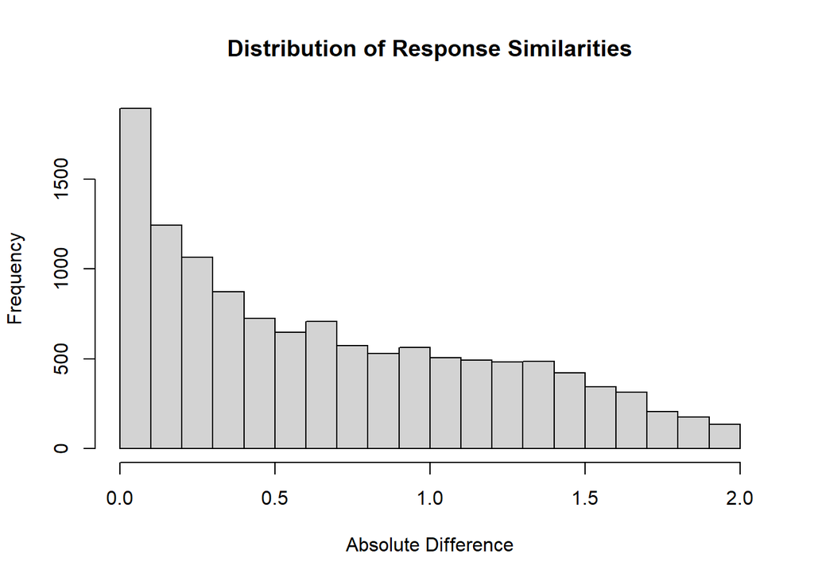

```r
# response similarity
data <- data %>%
  group_by(exp_ID) %>%
  mutate(difference = round(abs(c(0,diff(expressibility))), 4))

# value 0 for each first line of each participant --> should be 215 values of 0
participants_diff_0 <- unique(data$exp_ID[data$difference == 0]) # and indeed there is 215 zeros
# filter them out
difference <- subset(data, difference != 0)

# create a row number column
difference <- difference %>%
  mutate(row_number = row_number())

# summary statistics
hist(difference$difference, breaks = "FD", xlab = "Absolute Difference", main = "Distribution of Response Similarities")  # Plot histogram
```

```r
mean_diff <- mean(data$difference)  # Calculate mean difference - 0.66
sd_diff <- sd(data$difference)  # Calculate standard deviation of difference - 0.541

# let's set a treshold
threshold <- mean_diff - 1*sd_diff
straightlining_data <- difference[difference$difference < threshold, ]  # Filter responses below the threshold

# Find rows where the values in column 2 are increasing by 1 within gesture modality
increasing_rows_g <- straightlining_data[c(NA, diff(straightlining_data$row_number)) == 1 & straightlining_data$modality == "gesture", ]
# within vocal modality
increasing_rows_v <- straightlining_data[c(NA, diff(straightlining_data$row_number)) == 1 & straightlining_data$modality == "vocal", ]
# within multimodal modality
increasing_rows_m <- straightlining_data[c(NA, diff(straightlining_data$row_number)) == 1 & straightlining_data$modality == "multimodal", ]

# It seems like everyone did their best
```